# Memo - Natural Language Processing

## Natural Language Processing Introduction

[figure not shown]

from google.colab import drive drive.mount('/content/drive', force_remount=True)

## Model Resources

> [TensorFlow Hub](https://tfhub.dev/)  
> [fastText](https://fasttext.cc/)  
> [GPT-3](https://gpt3demo.com/product/gpt-3)

## OpenSource Ecosytem - Libraries

[figure not shown]

# Workflow

[figure not shown]

## Pre-processing - Spacy vs NLTK

[figure not shown]

### NLTK

```python
import nltk
```

```python
nltk.download('punkt')
```

```
True
```

```python
from nltk.tokenize import sent_tokenize
```

```python
sent_tokenize("An end to end NLP project consists of many steps. These steps together forms an NLP pipeline. The pipeline has various stages such as data acquisition, data cleaning, pre-processing, model building, deployment, monitor and update etc.")
```

```
['An end to end NLP project consists of many steps.',
 'These steps together forms an NLP pipeline.',
 'The pipeline has various stages such as data acquisition, data cleaning, pre-processing, model building, deployment, monitor and update etc.']
```

```python
from nltk.tokenize import word_tokenize
word_tokenize("An end to end NLP project consists of many steps.")
```

```
['An',
 'end',
 'to',
 'end',
 'NLP',
 'project',
 'consists',
 'of',
 'many',
 'steps',
 '.']
```

### Spacy

```python
import spacy
```

```python
!python -m spacy download en
```

```python
nlp = spacy.load('en_core_web_sm')
#nlp = spacy.blank("en")
```

```python
type(nlp)
```

```
spacy.lang.en.English
```

```python
text = "An end to end NLP project consists of many steps. These steps together forms an NLP pipeline. The pipeline has various stages such as data acquisition, data cleaning, pre-processing, model building, deployment, monitor and update etc."
```

```python
doc = nlp(text)
type(doc)
```

```
spacy.tokens.doc.Doc
```

```python
for sentence in doc.sents:
  print(sentence)
```

```
An end to end NLP project consists of many steps.
These steps together forms an NLP pipeline.
The pipeline has various stages such as data acquisition, data cleaning, pre-processing, model building, deployment, monitor and update etc.
```

```python
for word in sentence:
  print(word)
```

```
The
pipeline
has
various
stages
such
as
data
acquisition
,
data
cleaning
,
pre
-
processing
,
model
building
,
deployment
,
monitor
and
update
etc
.
```

```python
for token in doc:
   print(token)
```

```
An
end
to
end
NLP
project
consists
of
many
steps
.
These
steps
together
forms
an
NLP
pipeline
.
The
pipeline
has
various
stages
such
as
data
acquisition
,
data
cleaning
,
pre
-
processing
,
model
building
,
deployment
,
monitor
and
update
etc
.
```

```python
doc[0]
```

```
An
```

```python
doc[-1]
```

```
.
```

[figure not shown]

```python
token_0 = doc[0]
token_0
```

```
An
```

```python
type(token_0)
```

```
spacy.tokens.token.Token
```

```python
dir(token_0)
```

```
['_',
 '__bytes__',
 '__class__',
 '__delattr__',
 '__dir__',
 '__doc__',
 '__eq__',
 '__format__',
 '__ge__',
 '__getattribute__',
 '__gt__',
 '__hash__',
 '__init__',
 '__init_subclass__',
 '__le__',
 '__len__',
 '__lt__',
 '__ne__',
 '__new__',
 '__pyx_vtable__',
 '__reduce__',
 '__reduce_ex__',
 '__repr__',
 '__setattr__',
 '__sizeof__',
 '__str__',
 '__subclasshook__',
 '__unicode__',
 'ancestors',
 'check_flag',
 'children',
 'cluster',
 'conjuncts',
 'dep',
 'dep_',
 'doc',
 'ent_id',
 'ent_id_',
 'ent_iob',
 'ent_iob_',
```

[output cut: 67 more lines]

```
 'shape',
 'shape_',
 'similarity',
 'subtree',
 'suffix',
 'suffix_',
 'tag',
 'tag_',
 'tensor',
 'text',
 'text_with_ws',
 'vector',
 'vector_norm',
 'vocab',
 'whitespace_']
```

```python
token_0.text
```

```
'An'
```

```python
token_0.like_num
```

```
False
```

### **Pipeline in Spacy**

> !pip intall spacy  
> !python -m spacy download en  
> import spacy  
> nlp = spacy.load("en_core_web_sm")

> [NLP Pipeline: Building an NLP Pipeline, Step-by-Step](https://suneelpatel18.medium.com/nlp-pipeline-building-an-nlp-pipeline-step-by-step-7f0576e11d08)

[figure not shown]

```python
import spacy

nlp = spacy.blank("en")
```

```python
with open("data/student.txt", "r") as f:
    text = f.readlines()
print(text)
```

```
['Dayton high school, 8th grade students information\n', '==================================================\n', '\n', 'Name\tbirth day   \temail\n', '-----\t------------\t------\n', 'Virat   5 June, 1882    virat@kohli.com\n', 'Maria\t12 April, 2001  maria@sharapova.com\n', 'Serena  24 June, 1998  …
```

```python
text = " ".join(text)
text
```

```
'Dayton high school, 8th grade students information\n ==================================================\n \n Name\tbirth day   \temail\n -----\t------------\t------\n Virat   5 June, 1882    virat@kohli.com\n Maria\t12 April, 2001  maria@sharapova.com\n Serena  24 June, 1998   serena@williams.com \…
```

```python
doc = nlp(text)
emails = []
for token in doc:
    if token.like_email:
        emails.append(token)
emails
```

```
[virat@kohli.com, maria@sharapova.com, serena@williams.com, joe@root.com]
```

#### Customizing tokenizer

```python
doc = nlp("gimme double cheese extra large healthy pizza")
```

```python
tokens = [token for token in doc]
tokens
```

```
[gimme, double, cheese, extra, large, healthy, pizza]
```

```python
from spacy.symbols import ORTH

nlp.tokenizer.add_special_case("gimme", [
    {ORTH: "gim"},
    {ORTH: "me"},
])
doc = nlp("gimme double cheese extra large healthy pizza")
tokens = [token for token in doc]
tokens
```

```
[gim, me, double, cheese, extra, large, healthy, pizza]
```

```python
import spacy

nlp = spacy.blank("en")

doc = nlp("Captain america ate 100$ of samosa. Then he said I can do this all day.")

for token in doc:
    print(token)
```

```
Captain
america
ate
100
$
of
samosa
.
Then
he
said
I
can
do
this
all
day
.
```

```python
nlp = spacy.blank("en")

nlp.pipe_names
```

```
[]
```

```python
nlp = spacy.load('en_core_web_sm')

nlp.pipe_names
```

```
['tok2vec', 'tagger', 'parser', 'attribute_ruler', 'lemmatizer', 'ner']
```

```python
nlp.pipeline
```

```
[('tok2vec', <spacy.pipeline.tok2vec.Tok2Vec at 0x2351d837dc0>),
 ('tagger', <spacy.pipeline.tagger.Tagger at 0x2351d837fa0>),
 ('parser', <spacy.pipeline.dep_parser.DependencyParser at 0x2351d74a490>),
 ('attribute_ruler',
  <spacy.pipeline.attributeruler.AttributeRuler at 0x2351da6dd80>),
 ('lemmatizer', <spacy.lang.en.lemmatizer.EnglishLemmatizer at 0x2351da97980>),
 ('ner', <spacy.pipeline.ner.EntityRecognizer at 0x2351d74a420>)]
```

```python
doc = nlp("Captain america ate 100$ of samosa. Then he said I can do this all day.")

for token in doc:
    print(token, "  ", token.pos_, "  ", token.lemma_)
```

```
Captain    PROPN    Captain
america    PROPN    america
ate    VERB    eat
100    NUM    100
$    NOUN    $
of    ADP    of
samosa    PROPN    samosa
.    PUNCT    .
Then    ADV    then
he    PRON    he
said    VERB    say
I    PRON    I
can    AUX    can
do    VERB    do
this    PRON    this
all    DET    all
day    NOUN    day
.    PUNCT    .
```

```python
doc = nlp("Captain america ate 100$ of samosa. Then he said I can do this all day.")

for token in doc:
    print(token, "    ", spacy.explain(token.pos_), "   ", token.lemma_)
```

```
Captain      proper noun     Captain
america      proper noun     america
ate      verb     eat
100      numeral     100
$      noun     $
of      adposition     of
samosa      proper noun     samosa
.      punctuation     .
Then      adverb     then
he      pronoun     he
said      verb     say
I      pronoun     I
can      auxiliary     can
do      verb     do
this      pronoun     this
all      determiner     all
day      noun     day
.      punctuation     .
```

#### Adding a Customizing Component to a blank pipeline

```python
nlp_source = spacy.load("en_core_web_sm")

nlp = spacy.blank("en")

nlp.add_pipe("ner", source=nlp_source)

nlp.pipe_names
```

```
['ner']
```

```python
nlp.pipe_names
```

```
['ner']
```

```python
nlp_source = spacy.load("en_core_web_sm")

nlp = spacy.blank("en")

nlp.add_pipe("ner", source=nlp_source)

doc = nlp("Tesla Inc is going to acquire twitter for $45 billion")

for entity in doc.ents:
  print(entity.text, "    ", entity.label_, "   ", spacy.explain(entity.label_))
```

```
Tesla Inc      ORG     Companies, agencies, institutions, etc.
$45 billion      MONEY     Monetary values, including unit
```

### Stemming and Lemmatization

[figure not shown]

```python
import nltk
import spacy
```

```python
from nltk.stem import PorterStemmer
stemmer = PorterStemmer()
```

```python
words = ["eating", "eats", "eat", "ate", "adjustable", "rafting", "ability", "meeting"]

for word in words:
  print(word, "   ", stemmer.stem(word))
```

```
eating     eat
eats     eat
eat     eat
ate     ate
adjustable     adjust
rafting     raft
ability     abil
meeting     meet
```

```python
nlp = spacy.load("en_core_web_sm")

doc = nlp("eating eats eat ate adjustable rafting ability meeting better")

for token in doc:
  print(token, "    ", token.lemma_, "    ", token.lemma)
```

```
eating      eating      12092082220177030354
eats      eat      9837207709914848172
eat      eat      9837207709914848172
ate      eat      9837207709914848172
adjustable      adjustable      6033511944150694480
rafting      raft      7154368781129989833
ability      ability      11565809527369121409
meeting      meeting      14798207169164081740
better      well      4525988469032889948
```

```python
doc = nlp("Mando talked for 3 hours although talking isn't his thing")

for token in doc:
  print(token, "    ", token.lemma_, "    ", token.lemma)
```

```
Mando      mando      10991835832878170099
talked      talk      13939146775466599234
for      for      16037325823156266367
3      3      602994839685422785
hours      hour      9748623380567160636
although      although      343236316598008647
talking      talking      3577425109143670181
is      be      10382539506755952630
n't      not      447765159362469301
his      his      2661093235354845946
thing      thing      2473243759842082748
```

## Adding a Customizing token Component to pipeline

```python
nlp.pipe_names
```

```
['tok2vec', 'tagger', 'parser', 'attribute_ruler', 'lemmatizer', 'ner']
```

```python
ar = nlp.get_pipe("attribute_ruler")

doc = nlp("Bro, you wanna go? Brah, don't say no! I am exhausted")

for token in doc:
  print(token, "    ", token.lemma_, "    ", token.lemma)
```

```
Bro      Bro      16427154408071002123
,      ,      2593208677638477497
you      you      7624161793554793053
wanna      wanna      13000462173222681081
go      go      8004577259940138793
?      ?      8205403955989537350
Brah      Brah      5645766505577852541
,      ,      2593208677638477497
do      do      2158845516055552166
n't      not      447765159362469301
say      say      8685289367999165211
no      no      13055779130471031426
!      !      17494803046312582752
I      I      4690420944186131903
am      be      10382539506755952630
exhausted      exhaust      5738807065439247694
```

```python
ar = nlp.get_pipe("attribute_ruler")

ar.add([[{"TEXT":"Bro"}],[{"TEXT":"Brah"}]],{"LEMMA":"Brother"})

doc = nlp("Bro, you wanna go? Brah, don't say no! I am exhausted")

for token in doc:
  print(token, "    ", token.lemma_, "    ", token.lemma)
```

```
Bro      Brother      4347558510128575363
,      ,      2593208677638477497
you      you      7624161793554793053
wanna      wanna      13000462173222681081
go      go      8004577259940138793
?      ?      8205403955989537350
Brah      Brother      4347558510128575363
,      ,      2593208677638477497
do      do      2158845516055552166
n't      not      447765159362469301
say      say      8685289367999165211
no      no      13055779130471031426
!      !      17494803046312582752
I      I      4690420944186131903
am      be      10382539506755952630
exhausted      exhaust      5738807065439247694
```

### Part Of Speech(POS) Tagging

[figure not shown]

```python
nlp = spacy.load("en_core_web_sm")
doc = nlp("Elon flew to mars yesterday. He carried biryani masala with him")

for token in doc:
    print(token,"   ", token.pos_, "    ", spacy.explain(token.pos_), "   ", token.tag_, "    ", spacy.explain(token.tag_))
```

```
Elon     PROPN      proper noun     NNP      noun, proper singular
flew     VERB      verb     VBD      verb, past tense
to     ADP      adposition     IN      conjunction, subordinating or preposition
mars     NOUN      noun     NNS      noun, plural
yesterday     NOUN      noun     NN      noun, singular or mass
.     PUNCT      punctuation     .      punctuation mark, sentence closer
He     PRON      pronoun     PRP      pronoun, personal
carried     VERB      verb     VBD      verb, past tense
biryani     NOUN      noun     NN      noun, singular or mass
masala     NOUN      noun     NN      noun, singular or mass
with     ADP      adposition     IN      conjunction, subordinating or preposition
him     PRON      pronoun     PRP      pronoun, personal
```

```python
earnings_text="""Microsoft Corp. today announced the following results for the quarter ended December 31, 2021, as compared to the corresponding period of last fiscal year:

·         Revenue was $51.7 billion and increased 20%
·         Operating income was $22.2 billion and increased 24%
·         Net income was $18.8 billion and increased 21%
·         Diluted earnings per share was $2.48 and increased 22%
“Digital technology is the most malleable resource at the world’s disposal to overcome constraints and reimagine everyday work and life,” said Satya Nadella, chairman and chief executive officer of Microsoft. “As tech as a percentage of global GDP continues to increase, we are innovating and investing across diverse and growing markets, with a common underlying technology stack and an operating model that reinforces a common strategy, culture, and sense of purpose.”
“Solid commercial execution, represented by strong bookings growth driven by long-term Azure commitments, increased Microsoft Cloud revenue to $22.1 billion, up 32% year over year” said Amy Hood, executive vice president and chief financial officer of Microsoft."""

doc = nlp(earnings_text)

filted_tokens = []

for token in doc:
    if token.pos_ not in ["SACE", "PUNC"]:
        filted_tokens.append(token)

filted_tokens[:10]
```

```
[Microsoft,
 Corp.,
 today,
 announced,
 the,
 following,
 results,
 for,
 the,
 quarter]
```

```python
count = doc.count_by(spacy.attrs.POS)
count
```

```
{96: 15,
 92: 45,
 100: 22,
 90: 9,
 85: 16,
 93: 16,
 97: 27,
 98: 1,
 84: 21,
 103: 10,
 87: 6,
 99: 5,
 89: 12,
 86: 3,
 94: 3,
 95: 2}
```

```python
for k, v in count.items():
    print(doc.vocab[k].text, "   ", v)
```

```
PROPN     15
NOUN     45
VERB     22
DET     9
ADP     16
NUM     16
PUNCT     27
SCONJ     1
ADJ     21
SPACE     10
AUX     6
SYM     5
CCONJ     12
ADV     3
PART     3
PRON     2
```

### Named Entity Recognition (NER)

> [Introduction to Named Entity Recognition](https://ner.pythonhumanities.com/intro.html)  
> [Hugging Face](https://huggingface.co/dslim/bert-base-NER?text=Michael+Bloomberg+founded+Bloomberg+in+1982)

[figure not shown]

```python
import spacy
nlp = spacy.load("en_core_web_sm")
```

```python
nlp.pipe_names
```

```
['tok2vec', 'tagger', 'parser', 'attribute_ruler', 'lemmatizer', 'ner']
```

```python
doc = nlp("Tesla Inc is going to acquire twitter for $45 billion")

for entity in doc.ents:
    print(entity.text, "    ", entity.label_, "   ", spacy.explain(entity.label_))
```

```
Tesla Inc      ORG     Companies, agencies, institutions, etc.
$45 billion      MONEY     Monetary values, including unit
```

```python
from spacy import displacy

displacy.render(doc, style="ent")
```

Tesla Inc ORG is going to acquire twitter for $45 billion MONEY

```python
from spacy import displacy

displacy.render(doc, style="dep")
```

[figure not shown]

```python
nlp.pipe_labels["ner"]
```

```
['CARDINAL',
 'DATE',
 'EVENT',
 'FAC',
 'GPE',
 'LANGUAGE',
 'LAW',
 'LOC',
 'MONEY',
 'NORP',
 'ORDINAL',
 'ORG',
 'PERCENT',
 'PERSON',
 'PRODUCT',
 'QUANTITY',
 'TIME',
 'WORK_OF_ART']
```

```python
doc = nlp("Michael Bloomberg founded Bloomberg in 1982")

for entity in doc.ents:
    print(entity.text, "    ", entity.label_, "   ", spacy.explain(entity.label_))
```

```
Michael Bloomberg      PERSON     People, including fictional
Bloomberg      GPE     Countries, cities, states
1982      DATE     Absolute or relative dates or periods
```

### Adding a Customizing NER Component to pipeline

```python
doc = nlp("Tesla is going to acquire Twitter for $45 billion")

for entity in doc.ents:
    print(entity.text, "    ", entity.label_, "   ", spacy.explain(entity.label_))
```

```
Twitter      PERSON     People, including fictional
$45 billion      MONEY     Monetary values, including unit
```

```python
type(doc[0])
```

```
spacy.tokens.token.Token
```

```python
type(doc[2:5])
```

```
spacy.tokens.span.Span
```

```python
from spacy.tokens import Span

s1 = Span(doc, 0, 1, label="ORG")
s2 = Span(doc, 5, 6, label="ORG")

doc.set_ents([s1, s2], default="unmodified")
```

```python
for entity in doc.ents:
    print(entity.text, "    ", entity.label_, "   ", spacy.explain(entity.label_))
```

```
Tesla      ORG     Companies, agencies, institutions, etc.
Twitter      ORG     Companies, agencies, institutions, etc.
$45 billion      MONEY     Monetary values, including unit
```

## Feature Engineering

[figure not shown]

### Convert Text to Vector

[figure not shown]

### Text Classificatoin

> sentence-transformers/paraphrase-multilingual-MiniLM-L12-v2

[figure not shown]

### Cosine similarity, cosine distance explained

[figure not shown]

```python
from sklearn.metrics.pairwise import cosine_similarity, cosine_distances
```

```python
cosine_similarity([[3,1]],[[6,2]])
```

```
array([[1.]])
```

```python
cosine_distances([[3,1]],[[6,2]])
```

```
array([[1.11022302e-16]])
```

```python
cosine_similarity([[3,0]],[[0,8]])
```

```
array([[0.]])
```

```python
cosine_distances([[3,0]],[[0,8]])
```

```
array([[1.]])
```

### Text Representation - Bag Of Words (BOW)

[figure not shown]

```python
import numpy as np
import pandas as pd
```

```python
df = pd.read_csv('data/spam.csv')
df.head()
```

|  | Category | Message |
| --- | --- | --- |
| 0 | ham | Go until jurong point, crazy.. Available only ... |
| 1 | ham | Ok lar... Joking wif u oni... |
| 2 | spam | Free entry in 2 a wkly comp to win FA Cup fina... |
| 3 | ham | U dun say so early hor... U c already then say... |
| 4 | ham | Nah I don't think he goes to usf, he lives aro... |

```python
df['Category'].value_counts()
```

```
ham     4825
spam     747
Name: Category, dtype: int64
```

```python
df['Spam'] = df['Category'].apply(lambda x: 1 if x=='spam' else 0)
df.head()
```

|  | Category | Message | Spam |
| --- | --- | --- | --- |
| 0 | ham | Go until jurong point, crazy.. Available only ... | 0 |
| 1 | ham | Ok lar... Joking wif u oni... | 0 |
| 2 | spam | Free entry in 2 a wkly comp to win FA Cup fina... | 1 |
| 3 | ham | U dun say so early hor... U c already then say... | 0 |
| 4 | ham | Nah I don't think he goes to usf, he lives aro... | 0 |

## Model Building and Training

[figure not shown]

```python
from sklearn.model_selection import train_test_split
X_train, X_test, y_train, y_test = train_test_split(df['Message'], df['Spam'], test_size=0.2)
```

```python
type(X_train)
```

```
pandas.core.series.Series
```

```python
type(y_train)
```

```
pandas.core.series.Series
```

```python
type(X_train.values)
```

```
numpy.ndarray
```

```python
type(y_train.values)
```

```
numpy.ndarray
```

### Create bag of words representation using CountVectorizer

```python
from sklearn.feature_extraction.text import CountVectorizer

v = CountVectorizer()

X_train_cv = v.fit_transform(X_train.values)
```

```python
type(X_train_cv)
```

```
scipy.sparse._csr.csr_matrix
```

```python
X_train_cv.shape
```

```
(4457, 7799)
```

```python
dir(v)
```

```python
v.vocabulary_
```

```python
v.get_feature_names_out()[1000:1010]
```

```
array(['anything', 'anythingtomorrow', 'anytime', 'anyway', 'anyways',
       'anywhere', 'apart', 'apartment', 'apeshit', 'aphex'], dtype=object)
```

```python
X_train_np = X_train_cv.toarray()
X_train_np
```

```
array([[0, 0, 0, ..., 0, 0, 0],
       [0, 0, 0, ..., 0, 0, 0],
       [0, 0, 0, ..., 0, 0, 0],
       ...,
       [0, 0, 0, ..., 0, 0, 0],
       [0, 0, 0, ..., 0, 0, 0],
       [0, 0, 0, ..., 0, 0, 0]], dtype=int64)
```

```python
type(X_train_np)
```

```
numpy.ndarray
```

```python
np.where(X_train_np[0] != 0)
```

```
(array([3907, 4663, 4693, 4849, 5173, 5886, 6137, 6306, 6308, 6978, 7018,
        7262, 7541, 7696], dtype=int64),)
```

```python
X_train_np[0][1054]
```

```
0
```

```python
X_train[:4]
```

```
3292    I'm not smoking while people use "wylie smokes...
723                             That is wondar full flim.
5249        K I'm leaving soon, be there a little after 9
5253    Please tell me not all of my car keys are in y...
Name: Message, dtype: object
```

```python
v.get_feature_names_out()[2333]
```

```
'different'
```

```python
v.get_feature_names_out()[4539]
```

```
'missin'
```

#### Naive Bayes Classifier

[figure not shown]

```python
from sklearn.naive_bayes import MultinomialNB

model = MultinomialNB()

model.fit(X_train_cv, y_train)
```

```
MultinomialNB()
```

```python
X_test_cv = v.transform(X_test)
```

```python
y_preds = model.predict(X_test_cv)
```

```python
model.score(X_test_cv, y_test)
```

```
0.9847533632286996
```

```python
model.predict_proba(X_test_cv[:10])
```

```
array([[3.01293305e-02, 9.69870669e-01],
       [9.99410799e-01, 5.89201334e-04],
       [9.99999703e-01, 2.96768149e-07],
       [3.93373327e-11, 1.00000000e+00],
       [9.99999684e-01, 3.16156187e-07],
       [1.00000000e+00, 3.11023360e-15],
       [6.17426315e-15, 1.00000000e+00],
       [9.99999875e-01, 1.24821298e-07],
       [9.99999948e-01, 5.23724766e-08],
       [9.99999974e-01, 2.59966712e-08]])
```

```python
from sklearn.metrics import classification_report

print(classification_report(y_test, y_preds))
```

```
              precision    recall  f1-score   support

           0       0.99      1.00      0.99       968
           1       0.97      0.91      0.94       147

    accuracy                           0.98      1115
   macro avg       0.98      0.95      0.97      1115
weighted avg       0.98      0.98      0.98      1115
```

```python
emails = [
    'Hey mohan, can we get together to watch footbal game tomorrow?',
    'Upto 20% discount on parking, exclusive offer just for you. Dont miss this reward!'
]

emails_cv = v.transform(emails)

model.predict(emails_cv)
```

```
array([0, 1], dtype=int64)
```

```python
from sklearn.pipeline import Pipeline

model = Pipeline([
    ('vectorizer', CountVectorizer()),
    ('nb', MultinomialNB()),
])

model.fit(X_train, y_train)
```

```
Pipeline(steps=[('vectorizer', CountVectorizer()), ('nb', MultinomialNB())])
```

```python
model.score(X_test, y_test)
```

```
0.9847533632286996
```

```python
from sklearn.metrics import classification_report

y_preds = model.predict(X_test)

print(classification_report(y_test, y_preds))
```

```
              precision    recall  f1-score   support

           0       0.99      1.00      0.99       968
           1       0.97      0.91      0.94       147

    accuracy                           0.98      1115
   macro avg       0.98      0.95      0.97      1115
weighted avg       0.98      0.98      0.98      1115
```

### Text Representation - Stop Words

```python
from spacy.lang.en.stop_words import STOP_WORDS
STOP_WORDS
```

```python
len(STOP_WORDS)
```

```
326
```

```python
nlp = spacy.load("en_core_web_sm")
```

```python
doc = nlp("We just opened our wings, the flying part is coming soon")

for token in doc:
    if not token.is_stop and not token.is_punct:
        print(token)
```

```
opened
wings
flying
coming
soon
```

```python
def preprocess(text):
    doc = nlp(text)
    no_stop_words = [token.text for token in doc if not token.is_stop and not token.is_punct]
    return " ".join(no_stop_words)
```

```python
preprocess("We just opened our wings, the flying part is coming soon")
```

```
'opened wings flying coming soon'
```

```python
preprocess("Musk wants time to prepare for a trial over his")
```

```
'Musk wants time prepare trial'
```

```python
import numpy as np
import pandas as pd
```

```python
df = pd.read_json('data/doj_press.json', lines=True)
df.head()
```

|  | id | title | contents | date | topics | components |
| --- | --- | --- | --- | --- | --- | --- |
| 0 | None | Convicted Bomb Plotter Sentenced to 30 Years | PORTLAND, Oregon. – Mohamed Osman Mohamud, 23,... | 2014-10-01T00:00:00-04:00 | [] | [National Security Division (NSD)] |
| 1 | 12-919 | $1 Million in Restitution Payments Announced t... | WASHINGTON – North Carolina’s Waccamaw River... | 2012-07-25T00:00:00-04:00 | [] | [Environment and Natural Resources Division] |
| 2 | 11-1002 | $1 Million Settlement Reached for Natural Reso... | BOSTON– A $1-million settlement has been... | 2011-08-03T00:00:00-04:00 | [] | [Environment and Natural Resources Division] |
| 3 | 10-015 | 10 Las Vegas Men Indicted \r\nfor Falsifying V... | WASHINGTON—A federal grand jury in Las Vegas... | 2010-01-08T00:00:00-05:00 | [] | [Environment and Natural Resources Division] |
| 4 | 18-898 | $100 Million Settlement Will Speed Cleanup Wor... | The U.S. Department of Justice, the U.S. Envir... | 2018-07-09T00:00:00-04:00 | [Environment] | [Environment and Natural Resources Division] |

```python
df.info()
```

```
<class 'pandas.core.frame.DataFrame'>
RangeIndex: 13087 entries, 0 to 13086
Data columns (total 6 columns):
 #   Column      Non-Null Count  Dtype
---  ------      --------------  -----
 0   id          12810 non-null  object
 1   title       13087 non-null  object
 2   contents    13087 non-null  object
 3   date        13087 non-null  object
 4   topics      13087 non-null  object
 5   components  13087 non-null  object
dtypes: object(6)
memory usage: 613.6+ KB
```

```python
df = df[ df['topics'].str.len() != 0]
df.head()
```

|  | id | title | contents | date | topics | components |
| --- | --- | --- | --- | --- | --- | --- |
| 4 | 18-898 | $100 Million Settlement Will Speed Cleanup Wor... | The U.S. Department of Justice, the U.S. Envir... | 2018-07-09T00:00:00-04:00 | [Environment] | [Environment and Natural Resources Division] |
| 7 | 14-1412 | 14 Indicted in Connection with New England Com... | A 131-count criminal indictment was unsealed t... | 2014-12-17T00:00:00-05:00 | [Consumer Protection] | [Civil Division] |
| 19 | 17-1419 | 2017 Southeast Regional Animal Cruelty Prosecu... | The United States Attorney’s Office for the Mi... | 2017-12-14T00:00:00-05:00 | [Environment] | [Environment and Natural Resources Division, U... |
| 22 | 15-1562 | 21st Century Oncology to Pay $19.75 Million to... | 21st Century Oncology LLC, has agreed to pay $... | 2015-12-18T00:00:00-05:00 | [False Claims Act, Health Care Fraud] | [Civil Division] |
| 23 | 17-1404 | 21st Century Oncology to Pay $26 Million to Se... | 21st Century Oncology Inc. and certain of its ... | 2017-12-12T00:00:00-05:00 | [Health Care Fraud, False Claims Act] | [Civil Division, USAO - Florida, Middle] |

```python
df.info()
```

```
<class 'pandas.core.frame.DataFrame'>
Int64Index: 4688 entries, 4 to 13086
Data columns (total 6 columns):
 #   Column      Non-Null Count  Dtype
---  ------      --------------  -----
 0   id          4560 non-null   object
 1   title       4688 non-null   object
 2   contents    4688 non-null   object
 3   date        4688 non-null   object
 4   topics      4688 non-null   object
 5   components  4688 non-null   object
dtypes: object(6)
memory usage: 256.4+ KB
```

```python
df = df.head(100)
df["contents_new"] = df["contents"].apply(preprocess)
df.head()
```

|  | id | title | contents | date | topics | components | contents_new |
| --- | --- | --- | --- | --- | --- | --- | --- |
| 4 | 18-898 | $100 Million Settlement Will Speed Cleanup Wor... | The U.S. Department of Justice, the U.S. Envir... | 2018-07-09T00:00:00-04:00 | [Environment] | [Environment and Natural Resources Division] | U.S. Department Justice U.S. Environmental Pro... |
| 7 | 14-1412 | 14 Indicted in Connection with New England Com... | A 131-count criminal indictment was unsealed t... | 2014-12-17T00:00:00-05:00 | [Consumer Protection] | [Civil Division] | 131 count criminal indictment unsealed today B... |
| 19 | 17-1419 | 2017 Southeast Regional Animal Cruelty Prosecu... | The United States Attorney’s Office for the Mi... | 2017-12-14T00:00:00-05:00 | [Environment] | [Environment and Natural Resources Division, U... | United States Attorney Office Middle District ... |
| 22 | 15-1562 | 21st Century Oncology to Pay $19.75 Million to... | 21st Century Oncology LLC, has agreed to pay $... | 2015-12-18T00:00:00-05:00 | [False Claims Act, Health Care Fraud] | [Civil Division] | 21st Century Oncology LLC agreed pay $ 19.75 m... |
| 23 | 17-1404 | 21st Century Oncology to Pay $26 Million to Se... | 21st Century Oncology Inc. and certain of its ... | 2017-12-12T00:00:00-05:00 | [Health Care Fraud, False Claims Act] | [Civil Division, USAO - Florida, Middle] | 21st Century Oncology Inc. certain subsidiarie... |

```python
len(preprocess(df['contents'].iloc[4]))
```

```
4217
```

```python
len(df['contents'].iloc[4])
```

```
5504
```

### Text Representation - Bag Of n-grams

```python
from sklearn.feature_extraction.text import CountVectorizer

v = CountVectorizer()

v.fit(["Thor Hathodawala is looking for a job"])
```

```
CountVectorizer()
```

```python
v.vocabulary_
```

```
{'thor': 5, 'hathodawala': 1, 'is': 2, 'looking': 4, 'for': 0, 'job': 3}
```

```python
v = CountVectorizer(ngram_range=(2, 2))

v.fit(["Thor Hathodawala is looking for a job"])

v.vocabulary_
```

```
{'thor hathodawala': 4,
 'hathodawala is': 1,
 'is looking': 2,
 'looking for': 3,
 'for job': 0}
```

```python
import spacy

nlp = spacy.load("en_core_web_sm")

def preprocess(text):
    doc = nlp(text)
    filtered_tokens = []
    for token in doc:
        if token.is_stop or token.is_punct:
            continue
        filtered_tokens.append(token.lemma_)
    return " ".join(filtered_tokens)
```

```python
corpus = [
    "Thor ate pizza",
    "Loki is tall",
    "Loki is eating pizza"
]

corpus_processed = [preprocess(text) for text in corpus]
corpus_processed
```

```
['Thor eat pizza', 'Loki tall', 'Loki eat pizza']
```

```python
v = CountVectorizer(ngram_range=(1, 2))
v.fit(corpus_processed)
v.vocabulary_
```

```
{'thor': 7,
 'eat': 0,
 'pizza': 5,
 'thor eat': 8,
 'eat pizza': 1,
 'loki': 2,
 'tall': 6,
 'loki tall': 4,
 'loki eat': 3}
```

```python
v.transform(["Thor ate pizza"]).toarray()
```

```
array([[0, 0, 0, 0, 0, 1, 0, 1, 0]], dtype=int64)
```

### Categories Classification

```python
import numpy as np
import pandas as pd
```

```python
df = pd.read_json('data/news_dataset.json')
df.head()
```

|  | text | category |
| --- | --- | --- |
| 0 | Watching Schrödinger's Cat Die University of C... | SCIENCE |
| 1 | WATCH: Freaky Vortex Opens Up In Flooded Lake | SCIENCE |
| 2 | Entrepreneurs Today Don't Need a Big Budget to... | BUSINESS |
| 3 | These Roads Could Recharge Your Electric Car A... | BUSINESS |
| 4 | Civilian 'Guard' Fires Gun While 'Protecting' ... | CRIME |

```python
df.info()
```

```
<class 'pandas.core.frame.DataFrame'>
Int64Index: 12695 entries, 0 to 12694
Data columns (total 2 columns):
 #   Column    Non-Null Count  Dtype
---  ------    --------------  -----
 0   text      12695 non-null  object
 1   category  12695 non-null  object
dtypes: object(2)
memory usage: 297.5+ KB
```

```python
df['category'].value_counts()
```

```
BUSINESS    4254
SPORTS      4167
CRIME       2893
SCIENCE     1381
Name: category, dtype: int64
```

```python
min_samples = 1381
df_BUSINESS = df[df['category']=="BUSINESS"].sample(min_samples, random_state=2022)
df_BUSINESS.shape
```

```
(1381, 2)
```

```python
df_SPORTS = df[df['category']=="SPORTS"].sample(min_samples, random_state=2022)
df_CRIME = df[df['category']=="CRIME"].sample(min_samples, random_state=2022)
df_SCIENCE = df[df['category']=="SCIENCE"].sample(min_samples, random_state=2022)
```

```python
df_balanced = pd.concat([df_BUSINESS, df_SPORTS, df_CRIME, df_SCIENCE], axis=0)
df_balanced['category'].value_counts()
```

```
BUSINESS    1381
SPORTS      1381
CRIME       1381
SCIENCE     1381
Name: category, dtype: int64
```

### Model Build and Train

```python
df_balanced['category_new'] = df_balanced['category'].map({
    "BUSINESS": 0,
    "SPORTS" : 1,
    "CRIME": 3,
    "SCIENCE": 4,
})
```

```python
from sklearn.model_selection import train_test_split
X_train, X_test, y_train, y_test = train_test_split(
    df_balanced['text'],
    df_balanced['category_new'],
    test_size=0.2,
    random_state=2022,
    stratify=df_balanced['category_new']
)
```

```python
y_train.value_counts()
```

```
4    1105
3    1105
0    1105
1    1104
Name: category_new, dtype: int64
```

```python
from sklearn.naive_bayes import MultinomialNB
from sklearn.pipeline import Pipeline
from sklearn.metrics import classification_report

model = Pipeline([
    ('vectorizer_bow', CountVectorizer(ngram_range=(1, 2))),
    ('multi NB', MultinomialNB()),
])

model.fit(X_train, y_train)
```

```
Pipeline(steps=[('vectorizer_bow', CountVectorizer(ngram_range=(1, 2))),
                ('multi NB', MultinomialNB())])
```

```python
model.score(X_test, y_test)
```

```
0.8244343891402715
```

```python
y_preds = model.predict(X_test)
```

```python
print(classification_report(y_test, y_preds))
```

```
              precision    recall  f1-score   support

           0       0.69      0.90      0.78       276
           1       0.95      0.74      0.83       277
           3       0.82      0.88      0.85       276
           4       0.92      0.78      0.84       276

    accuracy                           0.82      1105
   macro avg       0.85      0.82      0.83      1105
weighted avg       0.85      0.82      0.83      1105
```

### Using preprocessed text to train

```python
df_balanced['text_processed'] = df_balanced['text'].apply(preprocess)
```

```python
df_balanced.head()
```

|  | text | category | category_new | text_processed |
| --- | --- | --- | --- | --- |
| 11967 | GCC Business Leaders Remain Confident in the F... | BUSINESS | 0 | gcc Business leader remain Confident face Regi... |
| 2912 | From the Other Side; an Honest Review from Emp... | BUSINESS | 0 | Honest Review employee wake morning love impor... |
| 3408 | Mike McDerment, CEO of FreshBooks, Talks About... | BUSINESS | 0 | Mike McDerment ceo FreshBooks talk give build ... |
| 502 | How to Market Your Business While Traveling th... | BUSINESS | 0 | market business travel World recently amazing ... |
| 5279 | How to Leverage Intuition in Decision-making I... | BUSINESS | 0 | Leverage intuition decision making feel safe r... |

```python
from sklearn.model_selection import train_test_split
X_train, X_test, y_train, y_test = train_test_split(
    df_balanced['text_processed'],
    df_balanced['category_new'],
    test_size=0.2,
    random_state=2022,
    stratify=df_balanced['category_new']
)
```

```python
model = Pipeline([
    ('vectorizer_bow', CountVectorizer(ngram_range=(1, 2))),
    ('multi NB', MultinomialNB()),
])

model.fit(X_train, y_train)
```

```
Pipeline(steps=[('vectorizer_bow', CountVectorizer(ngram_range=(1, 2))),
                ('multi NB', MultinomialNB())])
```

```python
model.score(X_test, y_test)
```

```
0.860633484162896
```

```python
y_preds = model.predict(X_test)
print(classification_report(y_test, y_preds))
```

```
              precision    recall  f1-score   support

           0       0.80      0.88      0.84       276
           1       0.92      0.83      0.87       277
           3       0.83      0.92      0.87       276
           4       0.91      0.81      0.86       276

    accuracy                           0.86      1105
   macro avg       0.87      0.86      0.86      1105
weighted avg       0.87      0.86      0.86      1105
```

```python
from sklearn.metrics import confusion_matrix
cm = confusion_matrix(y_test, y_preds)
cm
```

```
array([[242,   9,  15,  10],
       [ 10, 230,  29,   8],
       [ 15,   1, 255,   5],
       [ 34,  10,   8, 224]], dtype=int64)
```

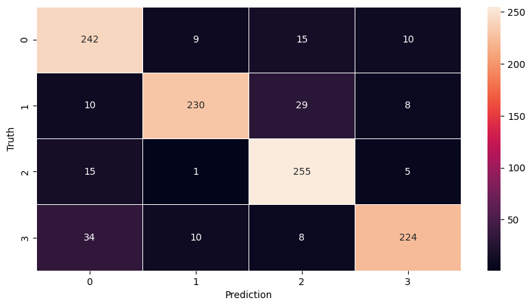

```python
import matplotlib.pyplot as plt
import seaborn as sn

plt.figure(figsize=(10,5))
sn.heatmap(
    cm,
    annot=True,
    fmt='d',
    linewidth=0.5
)
plt.xlabel('Prediction')
plt.ylabel('Truth')
```

### Text Representation - TF-IDF

[figure not shown]

```python
from sklearn.feature_extraction.text import TfidfVectorizer

v = TfidfVectorizer()

dir(v)
```

```python
corpus = [
    "Thor eating pizza, Loki is eating pizza, Ironman ate pizza already",
    "Apple is announcing new iphone tomorrow",
    "Tesla is announcing new model-3 tomorrow",
    "Google is announcing new pixel-6 tomorrow",
    "Microsoft is announcing new surface tomorrow",
    "Amazon is announcing new eco-dot tomorrow",
    "I am eating biryani and you are eating grapes"
]
```

```python
output_transformed = v.fit_transform(corpus)
```

```python
type(output_transformed)
```

```
scipy.sparse._csr.csr_matrix
```

```python
v.vocabulary_
```

```
{'thor': 25,
 'eating': 10,
 'pizza': 22,
 'loki': 17,
 'is': 16,
 'ironman': 15,
 'ate': 7,
 'already': 0,
 'apple': 5,
 'announcing': 4,
 'new': 20,
 'iphone': 14,
 'tomorrow': 26,
 'tesla': 24,
 'model': 19,
 'google': 12,
 'pixel': 21,
 'microsoft': 18,
 'surface': 23,
 'amazon': 2,
 'eco': 11,
 'dot': 9,
 'am': 1,
 'biryani': 8,
 'and': 3,
 'you': 27,
 'are': 6,
 'grapes': 13}
```

```python
all_feature_names = v.get_feature_names_out()
all_feature_names
```

```
array(['already', 'am', 'amazon', 'and', 'announcing', 'apple', 'are',
       'ate', 'biryani', 'dot', 'eating', 'eco', 'google', 'grapes',
       'iphone', 'ironman', 'is', 'loki', 'microsoft', 'model', 'new',
       'pixel', 'pizza', 'surface', 'tesla', 'thor', 'tomorrow', 'you'],
      dtype=object)
```

```python
v.idf_
```

```
array([2.38629436, 2.38629436, 2.38629436, 2.38629436, 1.28768207,
       2.38629436, 2.38629436, 2.38629436, 2.38629436, 2.38629436,
       1.98082925, 2.38629436, 2.38629436, 2.38629436, 2.38629436,
       2.38629436, 1.13353139, 2.38629436, 2.38629436, 2.38629436,
       1.28768207, 2.38629436, 2.38629436, 2.38629436, 2.38629436,
       2.38629436, 1.28768207, 2.38629436])
```

```python
for word in all_feature_names:
    index = v.vocabulary_.get(word)
    print(f"{word}:  {v.idf_[index]}")
```

```
already:  2.386294361119891
am:  2.386294361119891
amazon:  2.386294361119891
and:  2.386294361119891
announcing:  1.2876820724517808
apple:  2.386294361119891
are:  2.386294361119891
ate:  2.386294361119891
biryani:  2.386294361119891
dot:  2.386294361119891
eating:  1.9808292530117262
eco:  2.386294361119891
google:  2.386294361119891
grapes:  2.386294361119891
iphone:  2.386294361119891
ironman:  2.386294361119891
is:  1.1335313926245225
loki:  2.386294361119891
microsoft:  2.386294361119891
model:  2.386294361119891
new:  1.2876820724517808
pixel:  2.386294361119891
pizza:  2.386294361119891
surface:  2.386294361119891
tesla:  2.386294361119891
thor:  2.386294361119891
tomorrow:  1.2876820724517808
you:  2.386294361119891
```

```python
output_transformed[:2]
```

```
<2x28 sparse matrix of type '<class 'numpy.float64'>'
	with 14 stored elements in Compressed Sparse Row format>
```

```python
output_transformed.toarray()[:2]
```

```
array([[0.24266547, 0.        , 0.        , 0.        , 0.        ,
        0.        , 0.        , 0.24266547, 0.        , 0.        ,
        0.40286636, 0.        , 0.        , 0.        , 0.        ,
        0.24266547, 0.11527033, 0.24266547, 0.        , 0.        ,
        0.        , 0.        , 0.72799642, 0.        , 0.        ,
        0.24266547, 0.        , 0.        ],
       [0.        , 0.        , 0.        , 0.        , 0.30652086,
        0.5680354 , 0.        , 0.        , 0.        , 0.        ,
        0.        , 0.        , 0.        , 0.        , 0.5680354 ,
        0.        , 0.26982671, 0.        , 0.        , 0.        ,
        0.30652086, 0.        , 0.        , 0.        , 0.        ,
        0.        , 0.30652086, 0.        ]])
```

```python
corpus[:2]
```

```
['Thor eating pizza, Loki is eating pizza, Ironman ate pizza already',
 'Apple is announcing new iphone tomorrow']
```

```python
df = pd.read_csv("data/Ecommerce_data.csv")
df.head()
```

|  | Text | label |
| --- | --- | --- |
| 0 | Urban Ladder Eisner Low Back Study-Office Comp... | Household |
| 1 | Contrast living Wooden Decorative Box,Painted ... | Household |
| 2 | IO Crest SY-PCI40010 PCI RAID Host Controller ... | Electronics |
| 3 | ISAKAA Baby Socks from Just Born to 8 Years- P... | Clothing & Accessories |
| 4 | Indira Designer Women's Art Mysore Silk Saree ... | Clothing & Accessories |

```python
df['label'].value_counts()
```

```
Household                 6000
Electronics               6000
Clothing & Accessories    6000
Books                     6000
Name: label, dtype: int64
```

```python
df['label_num'] = df['label'].map({
    'Household' : 0,
    'Books': 1,
    'Electronics': 2,
    'Clothing & Accessories': 3
})
df.head()
```

|  | Text | label | label_num |
| --- | --- | --- | --- |
| 0 | Urban Ladder Eisner Low Back Study-Office Comp... | Household | 0 |
| 1 | Contrast living Wooden Decorative Box,Painted ... | Household | 0 |
| 2 | IO Crest SY-PCI40010 PCI RAID Host Controller ... | Electronics | 2 |
| 3 | ISAKAA Baby Socks from Just Born to 8 Years- P... | Clothing & Accessories | 3 |
| 4 | Indira Designer Women's Art Mysore Silk Saree ... | Clothing & Accessories | 3 |

```python
X_train, X_test, y_train, y_test = train_test_split(
    df['Text'],
    df['label_num'],
    test_size=0.2, # 20% samples will go to test dataset
    random_state=2022,
    stratify=df.label_num
)
```

```python
from sklearn.neighbors import KNeighborsClassifier
from sklearn.pipeline import Pipeline

model = Pipeline([
    ('vectorizer_tfidf', TfidfVectorizer()),
    ('KNN', KNeighborsClassifier()),
])

model.fit(X_train, y_train)
```

```
Pipeline(steps=[('vectorizer_tfidf', TfidfVectorizer()),
                ('KNN', KNeighborsClassifier())])
```

```python
model.score(X_test, y_test)
```

```
0.9641666666666666
```

```python
from sklearn.metrics import classification_report

y_preds = model.predict(X_test)
print(classification_report(y_test, y_preds))
```

```
              precision    recall  f1-score   support

           0       0.95      0.96      0.95      1200
           1       0.97      0.95      0.96      1200
           2       0.97      0.97      0.97      1200
           3       0.97      0.98      0.97      1200

    accuracy                           0.96      4800
   macro avg       0.96      0.96      0.96      4800
weighted avg       0.96      0.96      0.96      4800
```

```python
y_test[:5]
```

```
20706    0
19166    2
15209    3
2462     1
6621     3
Name: label_num, dtype: int64
```

```python
y_preds[:5]
```

```
array([0, 2, 3, 1, 0], dtype=int64)
```

```python
from sklearn.naive_bayes import MultinomialNB
from sklearn.pipeline import Pipeline

model = Pipeline([
    ('vectorizer_tfidf', TfidfVectorizer()),
    ('Multi NB', MultinomialNB()),
])

model.fit(X_train, y_train)
```

```
Pipeline(steps=[('vectorizer_tfidf', TfidfVectorizer()),
                ('Multi NB', MultinomialNB())])
```

```python
model.score(X_test, y_test)
```

```
0.9602083333333333
```

```python
from sklearn.metrics import classification_report

y_preds = model.predict(X_test)
print(classification_report(y_test, y_preds))
```

```
              precision    recall  f1-score   support

           0       0.92      0.96      0.94      1200
           1       0.98      0.92      0.95      1200
           2       0.97      0.97      0.97      1200
           3       0.97      0.99      0.98      1200

    accuracy                           0.96      4800
   macro avg       0.96      0.96      0.96      4800
weighted avg       0.96      0.96      0.96      4800
```

```python
df['Text_processed'] = df['Text'].apply(preprocess)
```

```python
X_train, X_test, y_train, y_test = train_test_split(
    df['Text_processed'],
    df['label_num'],
    test_size=0.2, # 20% samples will go to test dataset
    random_state=2022,
    stratify=df.label_num
)
```

```python
from sklearn.naive_bayes import MultinomialNB
from sklearn.pipeline import Pipeline

model = Pipeline([
    ('vectorizer_tfidf', TfidfVectorizer()),
    ('Multi NB', MultinomialNB()),
])

model.fit(X_train, y_train)
```

```
Pipeline(steps=[('vectorizer_tfidf', TfidfVectorizer()),
                ('Multi NB', MultinomialNB())])
```

```python
from sklearn.metrics import confusion_matrix
cm = confusion_matrix(y_test, y_preds)
cm
```

```
array([[1156,    9,   18,   17],
       [  56, 1108,   21,   15],
       [  32,    8, 1160,    0],
       [  13,    1,    1, 1185]], dtype=int64)
```

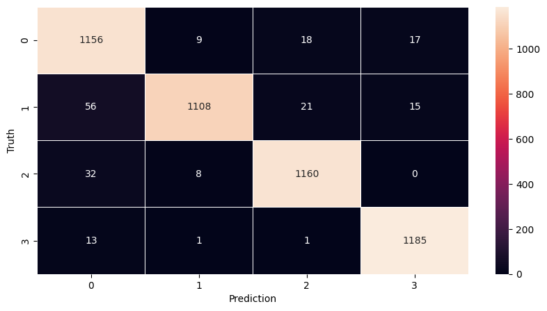

```python
import matplotlib.pyplot as plt
import seaborn as sn

plt.figure(figsize=(10,5))
sn.heatmap(
    cm,
    annot=True,
    fmt='d',
    linewidth=0.5
)
plt.xlabel('Prediction')
plt.ylabel('Truth')
```

### Text Representation - Word Embeddings

[figure not shown]

!python -m spacy download en_core_web_lg

```python
nlp = spacy.load("en_core_web_lg")
```

```python
doc = nlp("dog cat banana abcde")

for token in doc:
    print (token, " Vector: ", token.has_vector, " OOV: ", token.is_oov)
```

```
dog  Vector:  True  OOV:  False
cat  Vector:  True  OOV:  False
banana  Vector:  True  OOV:  False
abcde  Vector:  False  OOV:  True
```

```python
doc[0].vector.shape
```

```
(300,)
```

```python
token_base = nlp("bread")
token_base.vector.shape
```

```
(300,)
```

```python
doc = nlp("bread sandwich burger car tiger human wheat")

for token in doc:
    print(f"{token.text} <-> {token_base.text}, Similarity:", token.similarity(token_base))
```

```
bread <-> bread, Similarity: 1.0
sandwich <-> bread, Similarity: 0.6341067010130894
burger <-> bread, Similarity: 0.47520687769584247
car <-> bread, Similarity: 0.06451533308853552
tiger <-> bread, Similarity: 0.04764611675903374
human <-> bread, Similarity: 0.2151154210812192
wheat <-> bread, Similarity: 0.6150360888607199
```

```python
def print_similarity(word_base, words_to_compare):
    token_base = nlp(word_base)
    doc = nlp(words_to_compare)
    for token in doc:
        print(f"{token.text} <-> {token_base.text}, Similarity:", token.similarity(token_base))
```

```python
print_similarity("iphone", "apple samsung iphone dog kitten")
```

```
apple <-> iphone, Similarity: 0.4387907401919904
samsung <-> iphone, Similarity: 0.670859081425417
iphone <-> iphone, Similarity: 1.0
dog <-> iphone, Similarity: 0.08211864228011527
kitten <-> iphone, Similarity: 0.10222317834969896
```

```python
king = nlp.vocab["king"].vector
man = nlp.vocab["man"].vector
woman = nlp.vocab["woman"].vector
queen = nlp.vocab["queen"].vector

result = king - man + woman
```

```python
from sklearn.metrics.pairwise import cosine_similarity

cosine_similarity([result], [queen])
```

```
array([[0.61780137]], dtype=float32)
```

### Text Classification Using Spacy Word Embeddings

```python
import numpy as np
import pandas as pd
```

```python
df = pd.read_csv("data/Fake_Real_Data.csv")
df.head()
```

|  | Text | label |
| --- | --- | --- |
| 0 | Top Trump Surrogate BRUTALLY Stabs Him In The... | Fake |
| 1 | U.S. conservative leader optimistic of common ... | Real |
| 2 | Trump proposes U.S. tax overhaul, stirs concer... | Real |
| 3 | Court Forces Ohio To Allow Millions Of Illega... | Fake |
| 4 | Democrats say Trump agrees to work on immigrat... | Real |

```python
df.info()
```

```
<class 'pandas.core.frame.DataFrame'>
RangeIndex: 9900 entries, 0 to 9899
Data columns (total 2 columns):
 #   Column  Non-Null Count  Dtype
---  ------  --------------  -----
 0   Text    9900 non-null   object
 1   label   9900 non-null   object
dtypes: object(2)
memory usage: 154.8+ KB
```

```python
df['label'].value_counts()
```

```
Fake    5000
Real    4900
Name: label, dtype: int64
```

```python
df['label_num'] = df['label'].map({'Fake': 0, 'Real': 1})
```

```python
df.sample(5)
```

|  | Text | label | label_num |
| --- | --- | --- | --- |
| 8961 | Gala glitz masks Asia's tensions as Trump wind... | Real | 1 |
| 3230 | Kellyanne Conway Announces Trump’s HUGE ‘Than... | Fake | 0 |
| 2944 | Trump Boasts About Opening Of First New Coal ... | Fake | 0 |
| 8488 | U.S. taxpayers rush to claim deductions under ... | Real | 1 |
| 1661 | Trump faces obstacles in bid to re-shape key U... | Real | 1 |

```python
nlp = spacy.load("en_core_web_lg")
```

```python
df['vector'] = df['Text'].apply(lambda text: nlp(text).vector)
```

```python
df.info()
```

```
<class 'pandas.core.frame.DataFrame'>
RangeIndex: 9900 entries, 0 to 9899
Data columns (total 4 columns):
 #   Column     Non-Null Count  Dtype
---  ------     --------------  -----
 0   Text       9900 non-null   object
 1   label      9900 non-null   object
 2   label_num  9900 non-null   int64
 3   vector     9900 non-null   object
dtypes: int64(1), object(3)
memory usage: 309.5+ KB
```

### Train-Test splitting

```python
from sklearn.model_selection import train_test_split

X_train, X_test, y_train, y_test = train_test_split(
    df['vector'].values,
    df['label_num'],
    test_size=0.2,
    random_state=2022,
)
```

```python
X_train[0].shape
```

```
(300,)
```

### Reshaping the X_train and X_test so as to fit for models

```python
X_train_2d = np.stack(X_train)
X_test_2d = np.stack(X_test)
```

```python
X_train_2d.shape
```

```
(7920, 300)
```

```python
X_test_2d.shape
```

```
(1980, 300)
```

### Model Building and Training

```python
from sklearn.preprocessing import MinMaxScaler
from sklearn.naive_bayes import MultinomialNB


scaler = MinMaxScaler()
scaled_train_embed = scaler.fit_transform(X_train_2d)
scaled_test_embed = scaler.transform(X_test_2d)

model = MultinomialNB()
model.fit(scaled_train_embed, y_train)
```

```
MultinomialNB()
```

[figure not shown]

```python
model.score(scaled_test_embed, y_test)
```

```
0.943939393939394
```

```python
y_preds = model.predict(scaled_test_embed)

print(classification_report(y_test, y_preds))
```

```
              precision    recall  f1-score   support

           0       0.95      0.94      0.95      1024
           1       0.94      0.95      0.94       956

    accuracy                           0.94      1980
   macro avg       0.94      0.94      0.94      1980
weighted avg       0.94      0.94      0.94      1980
```

### KNN K nearest neighbors Classification

[figure not shown]

```python
from  sklearn.neighbors import KNeighborsClassifier

model = KNeighborsClassifier(n_neighbors = 5, metric = 'euclidean')

model.fit(X_train_2d, y_train)
```

```
KNeighborsClassifier(metric='euclidean')
```

```python
model.score(X_test_2d, y_test)
```

```
0.990909090909091
```

```python
y_preds = model.predict(X_test_2d)

print(classification_report(y_test, y_preds))
```

```
              precision    recall  f1-score   support

           0       1.00      0.99      0.99      1024
           1       0.99      0.99      0.99       956

    accuracy                           0.99      1980
   macro avg       0.99      0.99      0.99      1980
weighted avg       0.99      0.99      0.99      1980
```

```python
from sklearn.metrics import confusion_matrix
cm = confusion_matrix(y_test, y_preds)
cm
```

```
array([[1011,   13],
       [   5,  951]], dtype=int64)
```

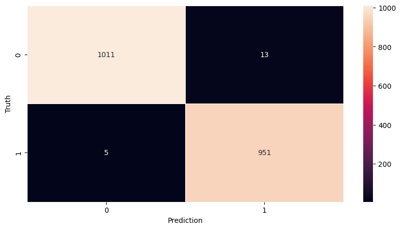

```python
plt.figure(figsize=(10,5))

sn.heatmap(
    cm,
    annot=True,
    fmt='d',
    linewidth=0.5
)

plt.xlabel('Prediction')
plt.ylabel('Truth')
```

### Word Vectors Overview Using Gensim Library

> [gensim models](https://github.com/RaRe-Technologies/gensim-data)  
> !pip install gensim

[figure not shown]

```python
import gensim.downloader as api
```

```python
wv = api.load('word2vec-google-news-300')
```

```python
wv.similarity(w1="great", w2="good")
```

```
0.729151
```

```python
wv.most_similar("good")
```

```
[('great', 0.7291510105133057),
 ('bad', 0.7190051078796387),
 ('terrific', 0.6889115571975708),
 ('decent', 0.6837348341941833),
 ('nice', 0.6836092472076416),
 ('excellent', 0.644292950630188),
 ('fantastic', 0.6407778263092041),
 ('better', 0.6120728850364685),
 ('solid', 0.5806034803390503),
 ('lousy', 0.576420247554779)]
```

```python
wv.most_similar(positive=['king', 'woman'], negative=['man'])
```

```
[('queen', 0.7118193507194519),
 ('monarch', 0.6189674139022827),
 ('princess', 0.5902431011199951),
 ('crown_prince', 0.5499460697174072),
 ('prince', 0.5377321839332581),
 ('kings', 0.5236844420433044),
 ('Queen_Consort', 0.5235945582389832),
 ('queens', 0.5181134343147278),
 ('sultan', 0.5098593831062317),
 ('monarchy', 0.5087411999702454)]
```

```python
wv.most_similar(positive=['king', 'woman'], negative=['man'], topn=5)
```

```
[('queen', 0.7118193507194519),
 ('monarch', 0.6189674139022827),
 ('princess', 0.5902431011199951),
 ('crown_prince', 0.5499460697174072),
 ('prince', 0.5377321839332581)]
```

```python
wv.most_similar(positive=['France', 'Berlin'], negative=['Paris'], topn=5)
```

```
[('Germany', 0.7901254892349243),
 ('Austria', 0.6026812195777893),
 ('German', 0.6004959940910339),
 ('Germans', 0.5851002931594849),
 ('Poland', 0.5847075581550598)]
```

```python
wv.doesnt_match(["facebook", "cat", "google", "microsoft"])
```

```
'cat'
```

```python
wv.doesnt_match(["dog", "cat", "google", "mouse"])
```

```
'google'
```

#### Gensim: Glove

> [GloVe](https://nlp.stanford.edu/projects/glove/)

```python
glv = api.load("glove-twitter-25")
```

```python
glv.most_similar("good")
```

```
[('too', 0.9648017287254333),
 ('day', 0.9533665180206299),
 ('well', 0.9503170847892761),
 ('nice', 0.9438973665237427),
 ('better', 0.9425962567329407),
 ('fun', 0.9418926239013672),
 ('much', 0.9413353800773621),
 ('this', 0.9387555122375488),
 ('hope', 0.9383506774902344),
 ('great', 0.9378516674041748)]
```

```python
glv.doesnt_match("breakfast cereal dinner lunch".split())
```

```
'cereal'
```

```python
glv.doesnt_match("facebook cat google microsoft".split())
```

```
'cat'
```

## Text Classification USing Gensim Word Embeddings

> [Dataset](https://www.kaggle.com/datasets/clmentbisaillon/fake-and-real-news-dataset)

[figure not shown]

### Using gensim's word2vec embeddings to convert text into vector

> 1. Preprocess the text to remove stop words, punctuations and get lemma for each word
> 2. Get word vectors for each of the words in a pre-processed sentece
> 3. Take a mean of all word vectors to derive the numeric representation of the entire news article

> import gensim.downloader as api  
> wv = api.load('word2vec-google-news-300')

```python
wv.similarity(w1="great", w2="good")
```

```
0.729151
```

```python
wv_great = wv["great"]
wv_good = wv["good"]
```

```python
wv_great.shape
```

```
(300,)
```

```python
type(wv_great)
```

```
numpy.ndarray
```

### Get Data

```python
df = pd.read_csv("data/fake_and_real_news.csv")
df.head()
```

|  | Text | label |
| --- | --- | --- |
| 0 | Top Trump Surrogate BRUTALLY Stabs Him In The... | Fake |
| 1 | U.S. conservative leader optimistic of common ... | Real |
| 2 | Trump proposes U.S. tax overhaul, stirs concer... | Real |
| 3 | Court Forces Ohio To Allow Millions Of Illega... | Fake |
| 4 | Democrats say Trump agrees to work on immigrat... | Real |

```python
df.info()
```

```
<class 'pandas.core.frame.DataFrame'>
RangeIndex: 9900 entries, 0 to 9899
Data columns (total 2 columns):
 #   Column  Non-Null Count  Dtype
---  ------  --------------  -----
 0   Text    9900 non-null   object
 1   label   9900 non-null   object
dtypes: object(2)
memory usage: 154.8+ KB
```

```python
df['label'].value_counts()
```

```
Fake    5000
Real    4900
Name: label, dtype: int64
```

```python
df['label_num'] = df['label'].map({
    "Fake": 0,
    "Real": 1
})
df.head()
```

|  | Text | label | label_num |
| --- | --- | --- | --- |
| 0 | Top Trump Surrogate BRUTALLY Stabs Him In The... | Fake | 0 |
| 1 | U.S. conservative leader optimistic of common ... | Real | 1 |
| 2 | Trump proposes U.S. tax overhaul, stirs concer... | Real | 1 |
| 3 | Court Forces Ohio To Allow Millions Of Illega... | Fake | 0 |
| 4 | Democrats say Trump agrees to work on immigrat... | Real | 1 |

```python
df.info()
```

```
<class 'pandas.core.frame.DataFrame'>
RangeIndex: 9900 entries, 0 to 9899
Data columns (total 3 columns):
 #   Column     Non-Null Count  Dtype
---  ------     --------------  -----
 0   Text       9900 non-null   object
 1   label      9900 non-null   object
 2   label_num  9900 non-null   int64
dtypes: int64(1), object(2)
memory usage: 232.2+ KB
```

### convert the text into a vector

```python
import spacy
nlp = spacy.load("en_core_web_lg")

def preprocess_and_vectorize(text):
    doc = nlp(text)

    filtered_tokens = []

    for token in doc:
        if token.is_punct or token.is_stop:
            continue
        filtered_tokens.append(token.lemma_)

    return filtered_tokens
```

```python
preprocess_and_vectorize("Don't worry if you don't understand")
```

```
['worry', 'understand']
```

```python
wv.get_mean_vector(['worry', 'understand'], pre_normalize=False)[:5]
```

```
array([ 0.00976562, -0.00561523, -0.08905029,  0.01330566, -0.2709961 ],
      dtype=float32)
```

```python
v1 = wv['worry']
v2 = wv['understand']
np.mean([v1, v2], axis=0)[:5]
```

```
array([ 0.00976562, -0.00561523, -0.08905029,  0.01330566, -0.2709961 ],
      dtype=float32)
```

```python
import spacy
nlp = spacy.load("en_core_web_lg")

def preprocess_and_vectorize(text):
    doc = nlp(text)

    filtered_tokens = []

    for token in doc:
        if token.is_punct or token.is_stop:
            continue
        filtered_tokens.append(token.lemma_)

    return wv.get_mean_vector(filtered_tokens)
```

```python
v = preprocess_and_vectorize("Don't worry if you don't understand")
v.shape
```

```
(300,)
```

```python
df['vector'] = df['Text'].apply(preprocess_and_vectorize)
#df['vector_text'] = df['Text'].apply(lambda text: preprocess_and_vectorize(text))
```

```python
df.head()
```

|  | Text | label | label_num | vector |
| --- | --- | --- | --- | --- |
| 0 | Top Trump Surrogate BRUTALLY Stabs Him In The... | Fake | 0 | [0.008145372, 0.019952843, -0.00989356, 0.0344... |
| 1 | U.S. conservative leader optimistic of common ... | Real | 1 | [0.00861828, 0.007408227, 0.0007675802, 0.0138... |
| 2 | Trump proposes U.S. tax overhaul, stirs concer... | Real | 1 | [0.01823076, 0.0063306373, -0.0058634086, 0.03... |
| 3 | Court Forces Ohio To Allow Millions Of Illega... | Fake | 0 | [0.012453172, 0.0122098895, 6.3027373e-06, 0.0... |
| 4 | Democrats say Trump agrees to work on immigrat... | Real | 1 | [-0.0022669104, 0.011340516, 0.003596399, 0.02... |

### Train-Test splitting

```python
from sklearn.model_selection import train_test_split

X_train, X_test, y_train, y_test = train_test_split(
    df['vector'].values,
    df['label_num'],
    test_size=0.2,
    random_state=2022,
    stratify=df['label_num']
)
```

### Reshaping the X_train and X_test to fit model

```python
X_train[:3]
```

```python
X_train_2d = np.stack(X_train)
X_test_2d =  np.stack(X_test)
```

```python
X_train_2d[:3]
```

### Model Building and Training

#### Gradient Boosting Classifier

[figure not shown]

```python
from sklearn.ensemble import GradientBoostingClassifier

model = GradientBoostingClassifier()

model.fit(X_train_2d, y_train)
```

```
GradientBoostingClassifier()
```

```python
model.score(X_test_2d, y_test)
```

```
0.9782828282828283
```

```python
y_preds = model.predict(X_test_2d)
```

```python
from sklearn.metrics import classification_report
print(classification_report(y_test, y_preds))
```

```
              precision    recall  f1-score   support

           0       0.98      0.97      0.98      1000
           1       0.97      0.98      0.98       980

    accuracy                           0.98      1980
   macro avg       0.98      0.98      0.98      1980
weighted avg       0.98      0.98      0.98      1980
```

### Test

```python
test_news = [
    "Michigan governor denies misleading U.S. House on Flint water (Reuters) - Michigan Governor Rick Snyder denied Thursday that he had misled a U.S. House of Representatives committee last year over testimony on Flintâ€™s water crisis after lawmakers asked if his testimony had been contradicted by a witness in a court hearing. The House Oversight and Government Reform Committee wrote Snyder earlier Thursday asking him about published reports that one of his aides, Harvey Hollins, testified in a court hearing last week in Michigan that he had notified Snyder of an outbreak of Legionnairesâ€™ disease linked to the Flint water crisis in December 2015, rather than 2016 as Snyder had testified. â€œMy testimony was truthful and I stand by it,â€ Snyder told the committee in a letter, adding that his office has provided tens of thousands of pages of records to the committee and would continue to cooperate fully.  Last week, prosecutors in Michigan said Dr. Eden Wells, the stateâ€™s chief medical executive who already faced lesser charges, would become the sixth current or former official to face involuntary manslaughter charges in connection with the crisis. The charges stem from more than 80 cases of Legionnairesâ€™ disease and at least 12 deaths that were believed to be linked to the water in Flint after the city switched its source from Lake Huron to the Flint River in April 2014. Wells was among six current and former Michigan and Flint officials charged in June. The other five, including Michigan Health and Human Services Director Nick Lyon, were charged at the time with involuntary manslaughter",
    " WATCH: Fox News Host Loses Her Sh*t, Says Investigating Russia For Hacking Our Election Is Unpatriotic This woman is insane.In an incredibly disrespectful rant against President Obama and anyone else who supports investigating Russian interference in our election, Fox News host Jeanine Pirro said that anybody who is against Donald Trump is anti-American. Look, it s time to take sides,  she began.",
    " Sarah Palin Celebrates After White Man Who Pulled Gun On Black Protesters Goes Unpunished (VIDEO) Sarah Palin, one of the nigh-innumerable  deplorables  in Donald Trump s  basket,  almost outdid herself in terms of horribleness on Friday."
]
```

```python
test_news_vectors = [preprocess_and_vectorize(n) for n in test_news]
```

```python
model.predict(test_news_vectors)
```

```
array([1, 0, 0], dtype=int64)
```

```python
from sklearn.metrics import confusion_matrix
cm = confusion_matrix(y_test, y_preds)
cm
```

```
array([[972,  28],
       [ 15, 965]], dtype=int64)
```

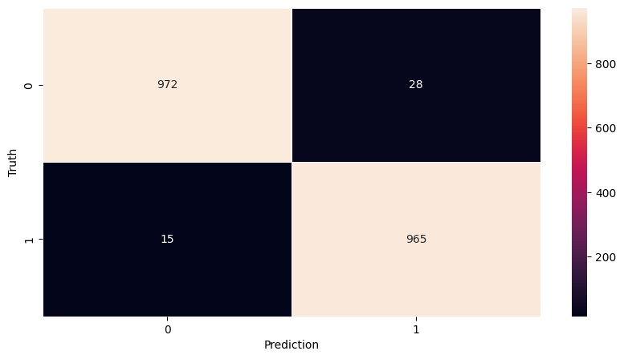

```python
plt.figure(figsize=(10,5))

sn.heatmap(
    cm,
    annot=True,
    fmt='d',
    linewidth=0.5
)

plt.xlabel('Prediction')
plt.ylabel('Truth')
```

### Train Custom Word Vectors in [fastText](https://fasttext.cc/docs/en/supervised-tutorial.html)

> git clone https://github.com/facebookresearch/fastText.git  
> cd fastText  
> pip install .  
> pip install fasttext pip install fastText

[figure not shown]

```python
df = pd.read_csv("data/Cleaned_Indian_Food_Dataset.csv")
df.head(3)
```

|  | TranslatedRecipeName | TranslatedIngredients | TotalTimeInMins | Cuisine | TranslatedInstructions | URL | Cleaned-Ingredients | image-url | Ingredient-count |
| --- | --- | --- | --- | --- | --- | --- | --- | --- | --- |
| 0 | Masala Karela Recipe | 1 tablespoon Red Chilli powder,3 tablespoon Gr... | 45 | Indian | To begin making the Masala Karela Recipe,de-se... | https://www.archanaskitchen.com/masala-karela-... | salt,amchur (dry mango powder),karela (bitter ... | https://www.archanaskitchen.com/images/archana... | 10 |
| 1 | Spicy Tomato Rice (Recipe) | 2 teaspoon cashew - or peanuts, 1/2 Teaspoon ... | 15 | South Indian Recipes | To make tomato puliogere, first cut the tomato... | https://www.archanaskitchen.com/spicy-tomato-r... | tomato,salt,chickpea lentils,green chilli,rice... | https://www.archanaskitchen.com/images/archana... | 12 |
| 2 | Ragi Semiya Upma Recipe - Ragi Millet Vermicel... | 1 Onion - sliced,1 teaspoon White Urad Dal (Sp... | 50 | South Indian Recipes | To begin making the Ragi Vermicelli Recipe, fi... | https://www.archanaskitchen.com/ragi-vermicell... | salt,rice vermicelli noodles (thin),asafoetida... | https://www.archanaskitchen.com/images/archana... | 12 |

```python
df.info()
```

```
<class 'pandas.core.frame.DataFrame'>
RangeIndex: 5938 entries, 0 to 5937
Data columns (total 9 columns):
 #   Column                  Non-Null Count  Dtype
---  ------                  --------------  -----
 0   TranslatedRecipeName    5938 non-null   object
 1   TranslatedIngredients   5938 non-null   object
 2   TotalTimeInMins         5938 non-null   int64
 3   Cuisine                 5938 non-null   object
 4   TranslatedInstructions  5938 non-null   object
 5   URL                     5938 non-null   object
 6   Cleaned-Ingredients     5938 non-null   object
 7   image-url               5938 non-null   object
 8   Ingredient-count        5938 non-null   int64
dtypes: int64(2), object(7)
memory usage: 417.6+ KB
```

```python
df['TranslatedInstructions'][0]
```

```
'To begin making the Masala Karela Recipe,de-seed the karela and slice.\r\nDo not remove the skin as the skin has all the nutrients.\r\nAdd the karela to the pressure cooker with 3 tablespoon of water, salt and turmeric powder and pressure cook for three whistles.\r\nRelease the pressure immediately…
```

### Pre-procesing - Use Regular Expression to Clean Data

> 1.Remove punctuation  
> 2.Remove extra space  
> 3.Make the entire sentence lower case

```python
import re

def preprocess(text):
    text = re.sub(r'[^\w\s]', ' ', text)
    text = re.sub(r'[ \r\n]+', ' ', text)
    return text.strip().lower()
```

```python
text = "To begin making the Masala Karela Recipe,de-seed the karela and slice.\r\nDo not remove the skin as the skin has all the nutrients.\r\nAdd the karela to the pressure cooker with 3 tablespoon of water, salt and turmeric powder and pressure cook for three whistles.\r\nRelease the pressure immediately and open the lids.\r\nKeep aside.Heat oil in a heavy bottomed pan or a kadhai.\r\nAdd cumin seeds and let it sizzle.Once the cumin seeds have sizzled, add onions and saute them till it turns golden brown in color.Add the karela, red chilli powder, amchur powder, coriander powder and besan.\r\nStir to combine the masalas into the karela.Drizzle a little extra oil on the top and mix again.\r\nCover the pan and simmer Masala Karela stirring occasionally until everything comes together well.\r\nTurn off the heat.Transfer Masala Karela into a serving bowl and serve.Serve Masala Karela along with Panchmel Dal and Phulka for a weekday meal with your family.\r\n"
```

```python
preprocess(text)
```

```
'to begin making the masala karela recipe de seed the karela and slice do not remove the skin as the skin has all the nutrients add the karela to the pressure cooker with 3 tablespoon of water salt and turmeric powder and pressure cook for three whistles release the pressure immediately and open the…
```

```python
df['TranslatedInstructions'] = df['TranslatedInstructions'].apply(preprocess)
```

```python
df.head()
```

|  | TranslatedRecipeName | TranslatedIngredients | TotalTimeInMins | Cuisine | TranslatedInstructions | URL | Cleaned-Ingredients | image-url | Ingredient-count |
| --- | --- | --- | --- | --- | --- | --- | --- | --- | --- |
| 0 | Masala Karela Recipe | 1 tablespoon Red Chilli powder,3 tablespoon Gr... | 45 | Indian | to begin making the masala karela recipe de se... | https://www.archanaskitchen.com/masala-karela-... | salt,amchur (dry mango powder),karela (bitter ... | https://www.archanaskitchen.com/images/archana... | 10 |
| 1 | Spicy Tomato Rice (Recipe) | 2 teaspoon cashew - or peanuts, 1/2 Teaspoon ... | 15 | South Indian Recipes | to make tomato puliogere first cut the tomatoe... | https://www.archanaskitchen.com/spicy-tomato-r... | tomato,salt,chickpea lentils,green chilli,rice... | https://www.archanaskitchen.com/images/archana... | 12 |
| 2 | Ragi Semiya Upma Recipe - Ragi Millet Vermicel... | 1 Onion - sliced,1 teaspoon White Urad Dal (Sp... | 50 | South Indian Recipes | to begin making the ragi vermicelli recipe fir... | https://www.archanaskitchen.com/ragi-vermicell... | salt,rice vermicelli noodles (thin),asafoetida... | https://www.archanaskitchen.com/images/archana... | 12 |
| 3 | Gongura Chicken Curry Recipe - Andhra Style Go... | 1/2 teaspoon Turmeric powder (Haldi),1 tablesp... | 45 | Andhra | to begin making gongura chicken curry recipe f... | https://www.archanaskitchen.com/gongura-chicke... | tomato,salt,ginger,sorrel leaves (gongura),fen... | https://www.archanaskitchen.com/images/archana... | 15 |
| 4 | Andhra Style Alam Pachadi Recipe - Adrak Chutn... | oil - as per use, 1 tablespoon coriander seed... | 30 | Andhra | to make andhra style alam pachadi first heat o... | https://www.archanaskitchen.com/andhra-style-a... | tomato,salt,ginger,red chillies,curry,asafoeti... | https://www.archanaskitchen.com/images/archana... | 12 |

```python
df['TranslatedInstructions'][0]
```

```
'to begin making the masala karela recipe de seed the karela and slice do not remove the skin as the skin has all the nutrients add the karela to the pressure cooker with 3 tablespoon of water salt and turmeric powder and pressure cook for three whistles release the pressure immediately and open the…
```

```python
df.to_csv("data/food_receipes.csv", columns=['TranslatedInstructions'], header=None, index=False)
```

```python
import fasttext

model = fasttext.train_unsupervised("data/food_receipes.csv")
```

```python
model.get_nearest_neighbors("paneer")
```

```
[(0.6278824806213379, 'bhurji'),
 (0.6183227896690369, 'tikka'),
 (0.6128366589546204, 'makhanwala'),
 (0.5976285934448242, 'tikkas'),
 (0.5888250470161438, 'makhane'),
 (0.5729339718818665, 'tandoori'),
 (0.568075954914093, 'reshmi'),
 (0.5664334297180176, 'makhani'),
 (0.5645010471343994, 'burji'),
 (0.5590397715568542, 'satay')]
```

```python
model.get_word_vector("dosa").shape
```

```
(100,)
```

### Text Classification Using fastText

```python
df= pd.read_csv("data/ecommerce_dataset.csv", header=None)
df.head()
```

|  | 0 | 1 |
| --- | --- | --- |
| 0 | Household | Paper Plane Design Framed Wall Hanging Motivat... |
| 1 | Household | SAF 'Floral' Framed Painting (Wood, 30 inch x ... |
| 2 | Household | SAF 'UV Textured Modern Art Print Framed' Pain... |
| 3 | Household | SAF Flower Print Framed Painting (Synthetic, 1... |
| 4 | Household | Incredible Gifts India Wooden Happy Birthday U... |

```python
df.columns=["category", "description"]
df.info()
```

```
<class 'pandas.core.frame.DataFrame'>
RangeIndex: 50425 entries, 0 to 50424
Data columns (total 2 columns):
 #   Column       Non-Null Count  Dtype
---  ------       --------------  -----
 0   category     50425 non-null  object
 1   description  50424 non-null  object
dtypes: object(2)
memory usage: 788.0+ KB
```

```python
df['category'].value_counts()
```

```
Household                 19313
Books                     11820
Electronics               10621
Clothing & Accessories     8671
Name: category, dtype: int64
```

```python
df.dropna(inplace=True)
df.shape
```

```
(50424, 2)
```

```python
df['category'].replace("Clothing & Accessories", "Clothing_Accessories", inplace=True)
df['category'].unique()
```

```
array(['Household', 'Books', 'Clothing_Accessories', 'Electronics'],
      dtype=object)
```

```python
df['category'] = "__label__" + df['category'].astype(str)
df.head()
```

|  | category | description |
| --- | --- | --- |
| 0 | __label__Household | Paper Plane Design Framed Wall Hanging Motivat... |
| 1 | __label__Household | SAF 'Floral' Framed Painting (Wood, 30 inch x ... |
| 2 | __label__Household | SAF 'UV Textured Modern Art Print Framed' Pain... |
| 3 | __label__Household | SAF Flower Print Framed Painting (Synthetic, 1... |
| 4 | __label__Household | Incredible Gifts India Wooden Happy Birthday U... |

```python
df.info()
```

```
<class 'pandas.core.frame.DataFrame'>
Int64Index: 50424 entries, 0 to 50424
Data columns (total 2 columns):
 #   Column       Non-Null Count  Dtype
---  ------       --------------  -----
 0   category     50424 non-null  object
 1   description  50424 non-null  object
dtypes: object(2)
memory usage: 1.2+ MB
```

```python
df['category_description'] = df['category'] + ' ' + df['description']
df.head()
```

|  | category | description | category_description |
| --- | --- | --- | --- |
| 0 | __label__Household | Paper Plane Design Framed Wall Hanging Motivat... | __label__Household Paper Plane Design Framed W... |
| 1 | __label__Household | SAF 'Floral' Framed Painting (Wood, 30 inch x ... | __label__Household SAF 'Floral' Framed Paintin... |
| 2 | __label__Household | SAF 'UV Textured Modern Art Print Framed' Pain... | __label__Household SAF 'UV Textured Modern Art... |
| 3 | __label__Household | SAF Flower Print Framed Painting (Synthetic, 1... | __label__Household SAF Flower Print Framed Pai... |
| 4 | __label__Household | Incredible Gifts India Wooden Happy Birthday U... | __label__Household Incredible Gifts India Wood... |

```python
df['category_description'][0]
```

```
'__label__Household Paper Plane Design Framed Wall Hanging Motivational Office Decor Art Prints (8.7 X 8.7 inch) - Set of 4 Painting made up in synthetic frame with uv textured print which gives multi effects and attracts towards it. This is an special series of paintings which makes your wall very …
```

### Pre-procesing - Use Regular Expression to Clean Data

> 1.Remove punctuation  
> 2.Remove extra space  
> 3.Make the entire sentence lower case

```python
df['category_description'] = df['category_description'].apply(preprocess)
```

```python
df['category_description'][0]
```

```
'__label__household paper plane design framed wall hanging motivational office decor art prints 8 7 x 8 7 inch set of 4 painting made up in synthetic frame with uv textured print which gives multi effects and attracts towards it this is an special series of paintings which makes your wall very beaut…
```

### Train Test Split

```python
from sklearn.model_selection import train_test_split

train, test = train_test_split(df, test_size=0.2)
```

```python
train.shape, test.shape
```

```
((40339, 3), (10085, 3))
```

```python
train.to_csv("data/ecommerce_train.csv", columns=["category_description"], index=False, header=False)
test.to_csv("data/ecommerce_test.csv", columns=["category_description"], index=False, header=False)
```

```python
import fasttext

model = fasttext.train_supervised(input="data/ecommerce_train.csv")
```

```python
model.test("data/ecommerce_test.csv")
```

```
(10085, 0.9699553792761527, 0.9699553792761527)
```

> - First parameter (10085) is test size. Second and third parameters are precision and recall respectively.

```python
model.predict("wintech assemble desktop pc cpu 500 gb sata hdd 4 gb ram intel c2d processor 3")
```

```
(('__label__electronics',), array([0.99772298]))
```

```python
model.predict("ockey men's cotton t shirt fabric details 80 cotton 20 polyester super combed cotton rich fabric")
```

```
(('__label__clothing_accessories',), array([1.00000703]))
```

### [BERT (Bidirectional Encoder Representations From Transformers)](https://medium.com/huggingface/introducing-fastbert-a-simple-deep-learning-library-for-bert-models-89ff763ad384)

[figure not shown]